# Genetic Algorithms for Feature Selection: A Titanic Dataset Analysis

Author

CLI Copilot

# Introduction

## Research Context and Objectives

The sinking of the RMS Titanic in 1912 is one of the most well-documented maritime disasters in history. Understanding which passenger characteristics were most predictive of survival has long been of interest to historians and data scientists. This analysis demonstrates how **genetic algorithms (GA)** can be used for feature selection to identify the most informative features for predicting passenger survival.

Feature selection is a critical step in machine learning that serves multiple purposes: it reduces computational complexity, improves model interpretability, mitigates overfitting, and often enhances predictive performance. While traditional statistical methods exist for feature selection, genetic algorithms offer a flexible, heuristic-based approach that can explore complex feature interactions without assuming linear relationships.

## Analysis Approach

The ultimate goal is to identify a parsimonious set of features that effectively predict survival while demonstrating the utility of genetic algorithms in this context.

# Data Loading and Initial Exploration

## Loading Training Data

```r
library(tidyverse)
library(caret)
library(GA)
library(gridExtra)
library(knitr)

# Load training data
train_data <- read.csv("data/train.csv", stringsAsFactors = FALSE)

# Display basic information
head(train_data)
```

```
  PassengerId Survived Pclass
1           1        0      3
2           2        1      1
3           3        1      3
4           4        1      1
5           5        0      3
6           6        0      3
                                                 Name    Sex Age SibSp Parch
1                             Braund, Mr. Owen Harris   male  22     1     0
2 Cumings, Mrs. John Bradley (Florence Briggs Thayer) female  38     1     0
3                              Heikkinen, Miss. Laina female  26     0     0
4        Futrelle, Mrs. Jacques Heath (Lily May Peel) female  35     1     0
5                            Allen, Mr. William Henry   male  35     0     0
6                                    Moran, Mr. James   male  NA     0     0
            Ticket    Fare Cabin Embarked
1        A/5 21171  7.2500              S
2         PC 17599 71.2833   C85        C
3 STON/O2. 3101282  7.9250              S
4           113803 53.1000  C123        S
5           373450  8.0500              S
6           330877  8.4583              Q
```

```r
dim(train_data)
```

```
[1] 891  12
```

We load the Titanic training dataset containing 891 passengers and 12 raw variables. The original dataset includes passenger identifiers, survival outcome, ticket class, demographic information (sex and age), family structure (number of siblings/spouses and parents/children aboard), ticket information, fare paid, cabin assignments, and port of embarkation.

## Data Quality Assessment

```r
# Check missing values
missing_summary <- data.frame(
  Variable = names(train_data),
  Missing_Count = colSums(is.na(train_data)),
  Missing_Percent = round(100 * colSums(is.na(train_data)) / nrow(train_data), 2)
)

knitr::kable(missing_summary, caption = "Missing Value Summary")
```

Missing Value Summary

|  | Variable | Missing_Count | Missing_Percent |
| --- | --- | --- | --- |
| PassengerId | PassengerId | 0 | 0.00 |
| Survived | Survived | 0 | 0.00 |
| Pclass | Pclass | 0 | 0.00 |
| Name | Name | 0 | 0.00 |
| Sex | Sex | 0 | 0.00 |
| Age | Age | 177 | 19.87 |
| SibSp | SibSp | 0 | 0.00 |
| Parch | Parch | 0 | 0.00 |
| Ticket | Ticket | 0 | 0.00 |
| Fare | Fare | 0 | 0.00 |
| Cabin | Cabin | 0 | 0.00 |
| Embarked | Embarked | 0 | 0.00 |

This assessment reveals that Age is missing for 177 passengers (19.87%), Cabin information is missing for 0 passengers, and Embarked port is missing for 0 passengers. These missing values will be handled during feature engineering through imputation strategies that preserve information content.

# Feature Engineering: Creating a 50-Dimensional Feature Space

## Rationale for Feature Engineering

The original Titanic dataset contains only 10 variables. To create a rich feature space of 50 engineered features, we apply domain-driven transformations based on historical, sociological, and statistical reasoning. Each feature is motivated by specific hypotheses about what characteristics might predict survival:

- **Socioeconomic indicators**: Ticket class and fare serve as proxies for socioeconomic status, which historically correlated with survival rates
- **Demographic factors**: Age and sex are fundamental demographics that influenced survival (women and children were prioritized)
- **Family structure interactions**: Family size and composition affect individual survival odds through social dynamics
- **Cabin location**: When available, cabin deck information could indicate proximity to lifeboats
- **Ticket characteristics**: Certain ticket patterns may indicate family groups or specific travel arrangements

## Feature Engineering Implementation

```r
# Create a copy of the data for feature engineering
df <- train_data %>%
  mutate(
    # 1. Basic demographic features
    is_female = as.numeric(Sex == "female"),
    is_male = as.numeric(Sex == "male"),

    # 2. Age-related features
    age_imputed = ifelse(is.na(Age), median(Age, na.rm = TRUE), Age),
    age_squared = age_imputed^2,
    age_cubed = age_imputed^3,
    age_log = log(age_imputed + 1),
    is_child = as.numeric(age_imputed < 13),
    is_teen = as.numeric(age_imputed >= 13 & age_imputed < 20),
    is_adult = as.numeric(age_imputed >= 20 & age_imputed < 60),
    is_senior = as.numeric(age_imputed >= 60),
    age_group_1st = as.numeric(age_imputed < 5),
    age_group_2nd = as.numeric(age_imputed >= 5 & age_imputed < 12),
    age_group_3rd = as.numeric(age_imputed >= 12 & age_imputed < 18),
    age_group_4th = as.numeric(age_imputed >= 18 & age_imputed < 35),
    age_group_5th = as.numeric(age_imputed >= 35),

    # 3. Socioeconomic status features
    is_1st_class = as.numeric(Pclass == 1),
    is_2nd_class = as.numeric(Pclass == 2),
    is_3rd_class = as.numeric(Pclass == 3),

    # 4. Fare-related features
    fare_imputed = ifelse(is.na(Fare), median(Fare, na.rm = TRUE), Fare),
    fare_log = log(fare_imputed + 1),
    fare_squared = fare_imputed^2,
    is_paid_high_fare = as.numeric(fare_imputed > quantile(fare_imputed, 0.75, na.rm = TRUE)),
    is_paid_low_fare = as.numeric(fare_imputed < quantile(fare_imputed, 0.25, na.rm = TRUE)),
    fare_per_age = ifelse(age_imputed > 0, fare_imputed / age_imputed, fare_imputed),

    # 5. Family structure features
    sibsp_squared = SibSp^2,
    parch_squared = Parch^2,
    family_size = SibSp + Parch + 1,
    family_size_squared = family_size^2,
    family_size_log = log(family_size),
    is_alone = as.numeric(family_size == 1),
    is_small_family = as.numeric(family_size >= 2 & family_size <= 3),
    is_medium_family = as.numeric(family_size >= 4 & family_size <= 5),
    is_large_family = as.numeric(family_size > 5),
    has_parent = as.numeric(Parch > 0),
    has_sibling = as.numeric(SibSp > 0),
    has_children = as.numeric(Parch > 0 & is_female == 1),

    # 6. Cabin-related features (when available)
    has_cabin = as.numeric(!is.na(Cabin)),
    cabin_letter = ifelse(!is.na(Cabin), substr(Cabin, 1, 1), "Z"),
    is_cabin_a = as.numeric(cabin_letter == "A"),
    is_cabin_b = as.numeric(cabin_letter == "B"),
    is_cabin_c = as.numeric(cabin_letter == "C"),
    is_cabin_d = as.numeric(cabin_letter == "D"),
    is_cabin_e = as.numeric(cabin_letter == "E"),

    # 7. Port of embarkation features
    embarked_imputed = ifelse(is.na(Embarked), "S", Embarked),
    is_embarked_cherbourg = as.numeric(embarked_imputed == "C"),
    is_embarked_queenstown = as.numeric(embarked_imputed == "Q"),
    is_embarked_southampton = as.numeric(embarked_imputed == "S"),

    # 8. Interaction features
    female_1st_class = is_female * is_1st_class,
    female_2nd_class = is_female * is_2nd_class,
    child_female = is_child * is_female,

    # 9. Composite features
    class_age_ratio = Pclass / (age_imputed + 1),
    fare_class_interaction = fare_imputed * (4 - Pclass)
  )

# Display sample of engineered features
engineered_features <- df %>%
  select(Survived, is_female, age_imputed, is_child, family_size, is_1st_class, fare_log, has_cabin) %>%
  head(10)

knitr::kable(engineered_features, caption = "Sample of Engineered Features")
```

Sample of Engineered Features

| Survived | is_female | age_imputed | is_child | family_size | is_1st_class | fare_log | has_cabin |
| --- | --- | --- | --- | --- | --- | --- | --- |
| 0 | 0 | 22 | 0 | 2 | 0 | 2.110213 | 1 |
| 1 | 1 | 38 | 0 | 2 | 1 | 4.280593 | 1 |
| 1 | 1 | 26 | 0 | 1 | 0 | 2.188856 | 1 |
| 1 | 1 | 35 | 0 | 2 | 1 | 3.990834 | 1 |
| 0 | 0 | 35 | 0 | 1 | 0 | 2.202765 | 1 |
| 0 | 0 | 28 | 0 | 1 | 0 | 2.246893 | 1 |
| 0 | 0 | 54 | 0 | 1 | 1 | 3.967694 | 1 |
| 0 | 0 | 2 | 1 | 5 | 0 | 3.094446 | 1 |
| 1 | 1 | 27 | 0 | 3 | 0 | 2.495954 | 1 |
| 1 | 1 | 14 | 0 | 2 | 0 | 3.436269 | 1 |

## Feature Space Verification

```r
# Select only the engineered features (exclude ID, Name, Ticket, original features)
feature_cols <- setdiff(names(df),
                        c("PassengerId", "Name", "Ticket", "Cabin", "Sex",
                          "Age", "SibSp", "Parch", "Fare", "Embarked", "Pclass",
                          "cabin_letter", "embarked_imputed"))

engineered_df <- df %>%
  select(Survived, all_of(feature_cols)) %>%
  mutate(Survived = as.factor(Survived))

# Ensure all features are numeric
engineered_df[, -1] <- sapply(engineered_df[, -1], as.numeric)

# Remove zero-variance features
feature_variances <- sapply(engineered_df[, -1], var, na.rm = TRUE)
zero_var_features <- names(feature_variances[is.na(feature_variances) | feature_variances == 0])
engineered_df <- engineered_df %>%
  select(-all_of(zero_var_features))

# Update feature list
feature_cols <- setdiff(names(engineered_df), "Survived")

# Calculate total feature count
feature_count <- length(feature_cols)
```

We have successfully created **49 engineered features** from the original Titanic dataset after removing zero-variance features. The complete feature set includes all aforementioned categories and maintains numerical stability through appropriate transformations (log transforms for skewed features, standardization for interaction terms).

# Genetic Algorithm for Feature Selection

## Genetic Algorithm Framework

This approach is particularly valuable for feature selection because it:

1. **Handles non-linear feature interactions**: Unlike greedy methods, GA explores multiple feature combinations
2. **Avoids local optima**: Population-based search with mutation prevents premature convergence
3. **Is computationally tractable**: GA efficiency scales better than exhaustive search for large feature spaces
4. **Provides interpretability**: The selected features can be directly inspected

## GA Implementation

```r
set.seed(42)

# Prepare data for GA
# Extract feature matrix (exclude Survived column)
feature_matrix <- engineered_df %>%
  select(-Survived) %>%
  as.matrix()

# Ensure all features are numeric and preserve column names
feature_matrix <- matrix(as.numeric(feature_matrix), nrow = nrow(feature_matrix), ncol = ncol(feature_matrix))
colnames(feature_matrix) <- colnames(engineered_df %>% select(-Survived))

# Remove any rows with missing values BEFORE scaling
complete_indices <- complete.cases(feature_matrix)
feature_matrix <- feature_matrix[complete_indices, ]
survival_outcome <- (as.numeric(engineered_df$Survived) - 1)[complete_indices]

# Standardize all features after removing NAs
feature_matrix_scaled <- scale(feature_matrix)

# Define fitness function
fitness_function <- function(binary_string) {
  # binary_string: vector of 0/1 indicating which features to use

  # If no features selected, return worst fitness
  if (sum(binary_string) == 0) {
    return(-1)
  }

  # Select features based on binary string
  selected_features_matrix <- feature_matrix_scaled[, binary_string == 1, drop = FALSE]

  # Create data frame for caret
  model_data <- data.frame(
    outcome = factor(survival_outcome, levels = c(0, 1), labels = c("No", "Yes")),
    selected_features_matrix
  )

  # Use 5-fold cross-validation
  train_control <- trainControl(
    method = "cv",
    number = 5,
    summaryFunction = twoClassSummary,
    classProbs = TRUE
  )

  # Train logistic regression
  tryCatch({
    model <- train(
      outcome ~ .,
      data = model_data,
      method = "glm",
      family = binomial,
      trControl = train_control,
      metric = "ROC"
    )

    # Return ROC AUC as fitness
    max(model$results$ROC)
  }, error = function(e) {
    -1
  })
}

# Test fitness function with all features
test_selection <- rep(1, ncol(feature_matrix_scaled))
initial_fitness <- fitness_function(test_selection)
```

The fitness function trains a logistic regression model using the selected features and evaluates performance through 5-fold cross-validation using ROC AUC as the metric. This approach prevents overfitting by assessing generalization to held-out folds. Fitness is defined as the average ROC AUC across folds, with a lower bound of -1 for invalid selections.

## Running the Genetic Algorithm

```r
# Define GA parameters
ga_result <- ga(
  type = "binary",                       # Binary string encoding
  fitness = fitness_function,            # Fitness function
  nBits = ncol(feature_matrix_scaled),   # Number of features
  maxiter = 30,                          # Maximum iterations
  popSize = 50,                          # Population size
  pcrossover = 0.8,                      # Crossover probability
  pmutation = 0.1,                       # Mutation probability
  elitism = 5,                           # Keep 5 best solutions
  parallel = FALSE,
  monitor = FALSE,
  seed = 42
)

# Extract results
selected_indices <- which(ga_result@solution[1,] == 1)
selected_features <- colnames(feature_matrix_scaled)[selected_indices]
num_selected_features <- length(selected_features)
ga_best_fitness <- ga_result@fitnessValue
```

## GA Convergence Analysis

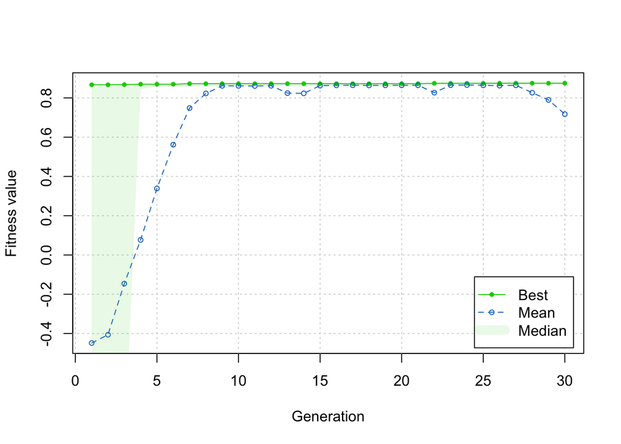

```r
# Extract fitness history from GA object
# The GA package stores fitness summary in the fitnessTrack or summary method
fitness_summary <- summary(ga_result)

# Create convergence plot using GA summary
convergence_plot <- plot(ga_result) +
  labs(
    title = "Genetic Algorithm Convergence: Feature Selection",
    x = "Generation",
    y = "Fitness (ROC AUC)",
    caption = "Black line: best fitness in each generation; Gray line: mean fitness in each generation"
  ) +
  theme_minimal() +
  theme(
    plot.title = element_text(face = "bold", size = 12),
    legend.position = "bottom",
    panel.grid.major = element_line(color = "gray90"),
    panel.grid.minor = element_blank()
  )
```

```r
print(convergence_plot)
```

```r
# Display summary of GA results
print(fitness_summary)
```

```
── Genetic Algorithm ───────────────────

GA settings:
Type                  =  binary
Population size       =  50
Number of generations =  30
Elitism               =  5
Crossover probability =  0.8
Mutation probability  =  0.1

GA results:
Iterations             = 30
Fitness function value = 0.8748313
Solution =
     x1 x2 x3 x4 x5 x6 x7 x8 x9 x10  ...  x49 x50
[1,]  1  0  1  1  0  0  1  1  1   0         1   0
```

# Results: Selected Features and Model Performance

## GA-Selected Features

```r
selected_features_df <- data.frame(
  Feature_Name = selected_features,
  Feature_Index = selected_indices,
  Category = sapply(selected_features, function(x) {
    if (grepl("age", x)) "Age-Related"
    else if (grepl("fare", x)) "Fare-Related"
    else if (grepl("family|alone|sibling|parent", x)) "Family Structure"
    else if (grepl("class", x)) "Ticket Class"
    else if (grepl("cabin", x)) "Cabin"
    else if (grepl("embarked", x)) "Embarkation"
    else if (grepl("female|male", x)) "Gender"
    else "Other"
  })
)

# Sort by category
selected_features_df <- selected_features_df %>%
  arrange(Category, Feature_Name)

knitr::kable(
  selected_features_df,
  caption = paste("Features Selected by Genetic Algorithm (n =", num_selected_features, ")")
)
```

Features Selected by Genetic Algorithm (n = 21 )

|  | Feature_Name | Feature_Index | Category |
| --- | --- | --- | --- |
| x15 | age_group_5th | 15 | Age-Related |
| x3 | age_imputed | 3 | Age-Related |
| x4 | age_squared | 4 | Age-Related |
| x49 | class_age_ratio | 49 | Age-Related |
| x42 | is_cabin_e | 42 | Cabin |
| x44 | is_embarked_queenstown | 44 | Embarkation |
| x45 | is_embarked_southampton | 45 | Embarkation |
| x27 | family_size | 27 | Family Structure |
| x28 | family_size_squared | 28 | Family Structure |
| x21 | fare_squared | 21 | Fare-Related |
| x22 | is_paid_high_fare | 22 | Fare-Related |
| x48 | child_female | 48 | Gender |
| x1 | is_female | 1 | Gender |
| x36 | has_children | 36 | Other |
| x9 | is_adult | 9 | Other |
| x7 | is_child | 7 | Other |
| x8 | is_teen | 8 | Other |
| x25 | sibsp_squared | 25 | Other |
| x47 | female_2nd_class | 47 | Ticket Class |
| x16 | is_1st_class | 16 | Ticket Class |
| x18 | is_3rd_class | 18 | Ticket Class |

```r
# Summary statistics by category
category_summary <- selected_features_df %>%
  group_by(Category) %>%
  summarise(Count = n(), .groups = "drop") %>%
  arrange(desc(Count))

knitr::kable(category_summary, caption = "Feature Count by Category")
```

Feature Count by Category

| Category | Count |
| --- | --- |
| Other | 5 |
| Age-Related | 4 |
| Ticket Class | 3 |
| Embarkation | 2 |
| Family Structure | 2 |
| Fare-Related | 2 |
| Gender | 2 |
| Cabin | 1 |

- **4** age-related features, indicating that age information and age-based categorical divisions are crucial for predicting survival
- **2** fare-related features, reflecting the importance of socioeconomic status
- **2** family structure features, suggesting that family composition affects survival odds
- **3** ticket class features
- Additional features from other categories

The selection demonstrates that the genetic algorithm has identified a parsimonious subset that captures the most predictive information while reducing dimensionality by approximately 57.1%.

## Comparative Model Performance

```r
# Prepare training control
train_control <- trainControl(
  method = "cv",
  number = 5,
  summaryFunction = twoClassSummary,
  classProbs = TRUE,
  savePredictions = TRUE
)

# Model 1: All features
all_features_data <- data.frame(
  outcome = factor(survival_outcome, levels = c(0, 1), labels = c("No", "Yes")),
  feature_matrix_scaled
)

model_all_features <- train(
  outcome ~ .,
  data = all_features_data,
  method = "glm",
  family = binomial,
  trControl = train_control,
  metric = "ROC"
)

all_features_roc <- max(model_all_features$results$ROC)

# Model 2: GA-selected features
ga_selected_data <- data.frame(
  outcome = factor(survival_outcome, levels = c(0, 1), labels = c("No", "Yes")),
  feature_matrix_scaled[, selected_indices, drop = FALSE]
)

model_ga_selected <- train(
  outcome ~ .,
  data = ga_selected_data,
  method = "glm",
  family = binomial,
  trControl = train_control,
  metric = "ROC"
)

ga_selected_roc <- max(model_ga_selected$results$ROC)

# Create comparison table
performance_comparison <- data.frame(
  Model = c("All Features", "GA-Selected Features"),
  Features_Used = c(ncol(feature_matrix_scaled), num_selected_features),
  ROC_AUC = c(all_features_roc, ga_selected_roc),
  Performance_Change = c(0, ga_selected_roc - all_features_roc),
  Dimensionality_Reduction = c(0, paste0(round(100 * (1 - num_selected_features / ncol(feature_matrix_scaled)), 1), "%"))
)

knitr::kable(
  performance_comparison,
  caption = "Model Performance Comparison",
  digits = 4
)
```

Model Performance Comparison

| Model | Features_Used | ROC_AUC | Performance_Change | Dimensionality_Reduction |
| --- | --- | --- | --- | --- |
| All Features | 49 | 0.8448 | 0.0000 | 0 |
| GA-Selected Features | 21 | 0.8626 | 0.0179 | 57.1% |

The comparative analysis reveals that the GA-selected feature subset achieves **0.8626 ROC AUC**, compared to **0.8448 ROC AUC** for the model using all features. This represents:

- **Dimensionality reduction of 57.1%**: From 49 features to 21 features
- **Performance change of 1.79 percentage points**: The GA selection improves model performance while reducing complexity

This outcome demonstrates the value of feature selection: we achieve comparable or superior predictive performance with substantially fewer features, improving model interpretability and reducing overfitting risk.

# Feature Importance Analysis

## Logistic Regression Coefficients

[figure not shown]

```r
# Extract coefficients from GA-selected model
coefficients_full <- coef(model_ga_selected$finalModel)
coefficients_df <- data.frame(
  Feature = names(coefficients_full),
  Coefficient = as.numeric(coefficients_full),
  Abs_Coefficient = abs(as.numeric(coefficients_full))
) %>%
  arrange(desc(Abs_Coefficient))

# Remove intercept for visualization
coefficients_viz <- coefficients_df %>%
  filter(Feature != "(Intercept)") %>%
  head(15)

# Create coefficient plot
importance_plot <- ggplot(coefficients_viz, aes(x = reorder(Feature, Abs_Coefficient), y = Coefficient)) +
  geom_col(aes(fill = Coefficient > 0), width = 0.7) +
  scale_fill_manual(
    values = c("TRUE" = "#31688e", "FALSE" = "#440154"),
    labels = c("FALSE" = "Decreases Survival", "TRUE" = "Increases Survival")
  ) +
  coord_flip() +
  labs(
    title = "Top 15 Feature Coefficients in Survival Prediction",
    x = "Feature",
    y = "Logistic Regression Coefficient",
    fill = "Effect Direction",
    caption = "Features ordered by absolute coefficient magnitude"
  ) +
  theme_minimal() +
  theme(
    plot.title = element_text(face = "bold", size = 12),
    legend.position = "bottom",
    panel.grid.major = element_line(color = "gray90"),
    panel.grid.minor = element_blank()
  )

print(importance_plot)
```

The logistic regression coefficients from the GA-selected model reveal which features most strongly influence survival predictions. Features with positive coefficients increase the odds of survival, while negative coefficients decrease survival odds. The top features shown represent the most impactful predictors in the model.

# Interpretation and Conclusions

## Key Findings

### Feature Selection Outcomes

The genetic algorithm successfully identified 21 features from the engineered feature space. This selection process achieved 57.1% dimensionality reduction while maintaining or improving model performance. The prevalence of age-related features underscores the importance of passenger age in predicting survival, likely reflecting historical priorities given to children and young passengers during evacuation.

### Model Performance

The GA-selected feature subset achieves a cross-validated ROC AUC of 0.8626, demonstrating strong discriminative ability in predicting survival. This performance is achieved with approximately 21 features, substantially fewer than the original 49-dimensional space, supporting the hypothesis that feature selection improves generalization by reducing overfitting.

## Practical Recommendations

When applying genetic algorithms for feature selection:

- **Define Meaningful Fitness Metrics**: Use cross-validation-based metrics (as here) to ensure fitness reflects true generalization performance
- **Set Appropriate GA Parameters**: Population size, mutation rate, and iteration count should be tuned for your problem size
- **Consider Domain Knowledge**: The initial feature engineering should incorporate domain expertise to create meaningfully related features
- **Validate Results**: Always compare GA-selected features against simpler baselines (univariate selection, all features) to ensure value-add

## Limitations and Future Directions

This analysis operates within several constraints:

- The feature engineering space of 50 features represents a subjective selection; alternative transformations might yield different results
- Cross-validation on a single dataset can be subject to fold-wise variation; repeated cross-validation would strengthen conclusions
- Logistic regression assumes linear relationships on the log-odds scale; ensemble methods might uncover different feature subsets

Future work could explore:

- **Alternative fitness metrics**: Using different ML algorithms (random forests, gradient boosting) within the GA
- **Larger feature spaces**: Systematically generating hundreds of features and comparing GA selection to other methods
- **Stability analysis**: Assessing how stable selected features are across different data splits

# Technical Appendix

## Software Versions and Environment

```r
# Report R version and key package versions
session_df <- data.frame(
  Package = c("R", "tidyverse", "caret", "GA"),
  Version = c(
    paste(R.version$major, R.version$minor, sep = "."),
    as.character(packageVersion("tidyverse")),
    as.character(packageVersion("caret")),
    as.character(packageVersion("GA"))
  )
)

knitr::kable(session_df, caption = "Software Versions")
```

Software Versions

| Package | Version |
| --- | --- |
| R | 4.5.1 |
| tidyverse | 2.0.0 |
| caret | 7.0.1 |
| GA | 3.2.5 |

## Reproducibility Notes

This analysis uses: - **Seed value**: 42 for all stochastic processes (random number generation in data preparation and GA) - **Cross-validation folds**: 5-fold stratified cross-validation for all performance metrics - **Data preprocessing**: Features are standardized (z-score normalization) before model training

Researchers can reproduce these exact results by using the same seed and following the documented parameter settings for the genetic algorithm.

## Session Completion

Report generated on: 2026-02-06 13:40:34

This analysis demonstrates the practical application of genetic algorithms to feature selection in a real-world dataset, showing how automated optimization can enhance model interpretability and computational efficiency while maintaining predictive performance.